# plotly

[Fork on Github](https://github.com/plotly/documentation/tree/source-design-merge//_posts/matplotlib/static-image)

# Matplotlib Static Image Export in matplotlib

How to export plotly matplotlib graphs as static images in Python. Plotly supports png, svg, jpg, and pdf image export.

#### New to Plotly?

Plotly's Python library is free and open source! [Get started](https://plot.ly/python/getting-started/) by downloading the client and [reading the primer](https://plot.ly/python/getting-started/).  
You can set up Plotly to work in [online](https://plot.ly/python/getting-started/#initialization-for-online-plotting) or [offline](https://plot.ly/python/getting-started/#initialization-for-offline-plotting) mode, or in [jupyter notebooks](https://plot.ly/python/getting-started/#start-plotting-online).  
We also have a quick-reference [cheatsheet](https://images.plot.ly/plotly-documentation/images/python_cheat_sheet.pdf) (new!) to help you get started!

#### Version Check

Plotly's python package is updated frequently. Run `pip install plotly --upgrade` to use the latest version.

```python
import plotly
plotly.__version__
```

```
'3.1.1'
```

```python
# Import modules
import plotly.plotly as py
import plotly.tools as tls
import matplotlib.pyplot as plt

# Create a plot
x = [1, 2]
y = [2, 4]
plt.plot(x, y)

# Get Matplotlib Figure
mpl_fig = plt.gcf()

# Convert to plotly figure
plotly_fig = tls.mpl_to_plotly(mpl_fig)

# Save image
py.image.save_as(plotly_fig, 'your_image_filename.png')
```

In Addition, you can specify the size of the matplotlib/plotly figure to be saved by using following method:

```python
import plotly.plotly as py
py.image.save_as(plotly_fig, 'your_image_filename.png', height=desired_height, width=desired_width)
```

You can also display inline static images in IPython:

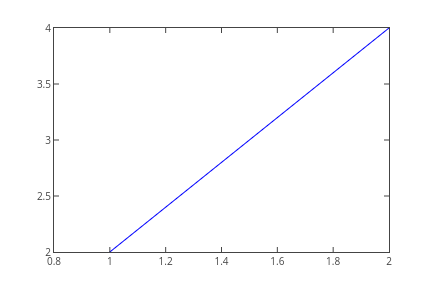

```python
import plotly.plotly as py
py.image.ishow(plotly_fig)
```

You can view the static version of any Plotly graph by appending `.png`, `.pdf`, `.eps`, or `.svg` to the end of the URL. For example, view the static image of https://plot.ly/~chris/1638 at https://plot.ly/~chris/1638.png.

Combine this with the requests package and download the latest version of your Plotly graph:

```python
import requests
image_bytes = requests.get('https://plot.ly/~chris/1638.png').content
```

### Reference

See https://plot.ly/python/static-image-export/ for more information and chart attribute options!

```python
help(py.image)
```

````
Help on class image in module plotly.plotly.plotly:

class image
 |  Helper functions wrapped around plotly's static image generation api.
 |  Class methods defined here:
 |  ishow(cls, figure_or_data, format='png', width=None, height=None, scale=None) from __builtin__.classobj
 |      Display a static image of the plot described by `figure_or_data`
 |      in an IPython Notebook.
 |      positional arguments:
 |      - figure_or_data: The figure dict-like or data list-like object that
 |                        describes a plotly figure.
 |                        Same argument used in `py.plot`, `py.iplot`,
 |                        see https://plot.ly/python for examples
 |      - format: 'png', 'svg', 'jpeg', 'pdf'
 |      - width: output width
 |      - height: output height
 |      - scale: Increase the resolution of the image by `scale` amount
 |             Only valid for PNG and JPEG images.
 |      example:
 |      ```
 |      import plotly.plotly as py
 |      fig = {'data': [{'x': [1, 2, 3], 'y': [3, 1, 5], 'type': 'bar'}]}
 |      py.image.ishow(fig, 'png', scale=3)
 |  save_as(cls, figure_or_data, filename, format=None, width=None, height=None, scale=None) from __builtin__.classobj
 |      Save a image of the plot described by `figure_or_data` locally as
 |      `filename`.
 |      Valid image formats are 'png', 'svg', 'jpeg', and 'pdf'.
 |      The format is taken as the extension of the filename or as the
 |      supplied format.
 |      positional arguments:
 |      - figure_or_data: The figure dict-like or data list-like object that
 |                        describes a plotly figure.
 |                        Same argument used in `py.plot`, `py.iplot`,
 |                        see https://plot.ly/python for examples
 |      - filename: The filepath to save the image to
 |      - format: 'png', 'svg', 'jpeg', 'pdf'
 |      - width: output width
 |      - height: output height
 |      - scale: Increase the resolution of the image by `scale` amount
 |             Only valid for PNG and JPEG images.
````

[output cut: 12 more lines]

````
 |                        describes a plotly figure.
 |                        Same argument used in `py.plot`, `py.iplot`,
 |                        see https://plot.ly/python for examples
 |      - format: 'png', 'svg', 'jpeg', 'pdf'
 |      - width: output width
 |      - height: output height
 |      - scale: Increase the resolution of the image by `scale`
 |               amount (e.g. `3`)
 |               Only valid for PNG and JPEG images.
 |      example:
 |      ```
 |      import plotly.plotly as py
 |      fig = {'data': [{'x': [1, 2, 3], 'y': [3, 1, 5], 'type': 'bar'}]}
 |      py.image.get(fig, 'png', scale=3)
 |      ```
````

Still need help?